# NYPD Shootings EDA

Swapnil Bhatta

2022-11-15

## How to get the data

Navigate to the dataset link https://catalog.data.gov/dataset and search for a dataset titled NYPD Shooting Incident Data (Historic). The data is automatically downloaded by the script.

```r
nypd_url <- "https://data.cityofnewyork.us/api/views/833y-fsy8/rows.csv?accessType=DOWNLOAD"
police_shootings <- read.csv(nypd_url,
                             header=TRUE,
                             sep=",")
```

```r
summary(police_shootings)
```

```
##   INCIDENT_KEY        OCCUR_DATE         OCCUR_TIME            BORO
##  Min.   :  9953245   Length:25596       Length:25596       Length:25596
##  1st Qu.: 61593633   Class :character   Class :character   Class :character
##  Median : 86437258   Mode  :character   Mode  :character   Mode  :character
##  Mean   :112382648
##  3rd Qu.:166660833
##  Max.   :238490103
##
##     PRECINCT      JURISDICTION_CODE LOCATION_DESC      STATISTICAL_MURDER_FLAG
##  Min.   :  1.00   Min.   :0.0000    Length:25596       Length:25596
##  1st Qu.: 44.00   1st Qu.:0.0000    Class :character   Class :character
##  Median : 69.00   Median :0.0000    Mode  :character   Mode  :character
##  Mean   : 65.87   Mean   :0.3316
##  3rd Qu.: 81.00   3rd Qu.:0.0000
##  Max.   :123.00   Max.   :2.0000
##                   NA's   :2
##  PERP_AGE_GROUP       PERP_SEX          PERP_RACE         VIC_AGE_GROUP
##  Length:25596       Length:25596       Length:25596       Length:25596
##  Class :character   Class :character   Class :character   Class :character
##  Mode  :character   Mode  :character   Mode  :character   Mode  :character
##
##
##
##
##    VIC_SEX            VIC_RACE           X_COORD_CD        Y_COORD_CD
##  Length:25596       Length:25596       Min.   : 914928   Min.   :125757
##  Class :character   Class :character   1st Qu.:1000011   1st Qu.:182782
##  Mode  :character   Mode  :character   Median :1007715   Median :194038
##                                        Mean   :1009455   Mean   :207894
##                                        3rd Qu.:1016838   3rd Qu.:239429
##                                        Max.   :1066815   Max.   :271128
##
##     Latitude       Longitude        Lon_Lat
##  Min.   :40.51   Min.   :-74.25   Length:25596
##  1st Qu.:40.67   1st Qu.:-73.94   Class :character
##  Median :40.70   Median :-73.92   Mode  :character
##  Mean   :40.74   Mean   :-73.91
##  3rd Qu.:40.82   3rd Qu.:-73.88
##  Max.   :40.91   Max.   :-73.70
##
```

## What cleaning process was used?

- Changed the type for OCCUR_DATE to date
- Removed unwanted columns

```r
# Remove unwanted columns
police_shootings <- select(police_shootings, -c(LOCATION_DESC, STATISTICAL_MURDER_FLAG, PERP_AGE_GROUP, X_COORD_CD, Y_COORD_CD, Lon_Lat))
```

```r
# Convert string to datetime
police_shootings$ OCCUR_DATE <- mdy(police_shootings$ OCCUR_DATE)
```

```r
# Add columns for monthly, yearly averages
police_shootings <- police_shootings %>%
    mutate(YEAR_MONTH = floor_date(police_shootings$ OCCUR_DATE, 'month')) %>%
    mutate(MONTH = strftime(police_shootings$ OCCUR_DATE, format='%m'))
```

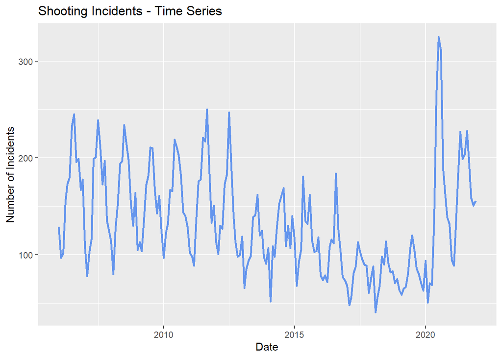

```r
date_value_counts <- police_shootings %>% count(YEAR_MONTH)
ggplot(date_value_counts, aes(x=YEAR_MONTH, y=n)) +
                        geom_line(color = "cornflowerblue", size=1) +
                        labs(x = "Date", y = "Number of Incidents", title='Shooting Incidents - Time Series')
```

```r
# Checking if some incidents are reported additional times for multiple shootings
incident_counts <- police_shootings %>% count(INCIDENT_KEY)
incident_counts[order(incident_counts$ n, decreasing = TRUE),] %>% head(10)
```

```
##       INCIDENT_KEY  n
## 15510    173354054 18
## 867       23749375 12
## 1209      24717013 12
## 2358      33478089 12
## 2428      33706902 12
## 2876      35803777 12
## 5578      66027258 12
## 6279      72195829 12
## 6362      72616285 12
## 7966      79378503 12
```

We see that an incident can have multiple data points, plotting only unique counts confirms that there might’ve been some outliers

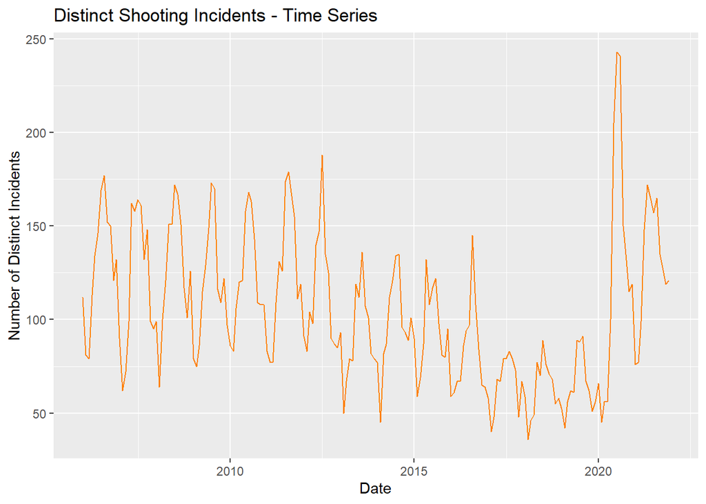

```r
distinct_year_month <- police_shootings %>% group_by(YEAR_MONTH) %>%
                    summarize(distinct_incident = n_distinct(INCIDENT_KEY))
ggplot(distinct_year_month, aes(x=YEAR_MONTH, y=distinct_incident)) +
                geom_line(color = "darkorange1") +
                labs(x = "Date", y = "Number of Distinct Incidents", title='Distinct Shooting Incidents - Time Series')
```

Visualizing overlap of incidents

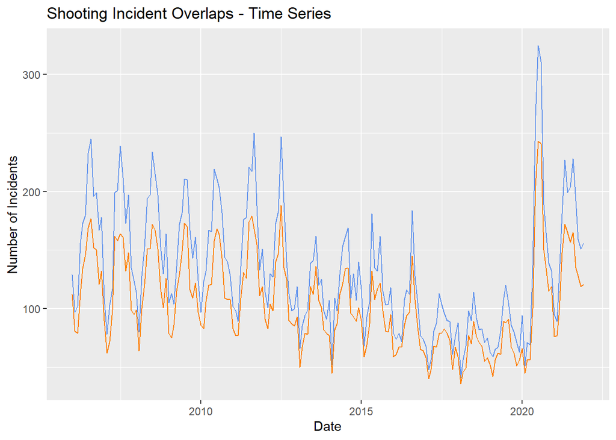

```r
ggplot(date_value_counts, aes(x=YEAR_MONTH, y=n)) +
                        geom_line(color = "cornflowerblue") +
                        geom_line(data = distinct_year_month, aes(x=YEAR_MONTH, y=distinct_incident), color = "darkorange1") +
                    labs(x = "Date", y = "Number of Incidents", title='Shooting Incident Overlaps - Time Series')
```

Hourly breakdown for shooting incidents

```
## `geom_line()`: Each group consists of only one observation.
## ℹ Do you need to adjust the group aesthetic?
```

[figure not shown]

```r
distinct_hours <- police_shootings %>% group_by(OCCUR_TIME) %>%
                    summarize(distinct_incident = n_distinct(INCIDENT_KEY))
ggplot(distinct_hours, aes(x=OCCUR_TIME,
                              y=distinct_incident)) + geom_line(color = "blue")+
                    labs(x = "Date", y = "Number of Incidents", title='Shooting Incident Overlaps - Time Series')+
                    labs(x = "Time (Hour)", y = "Number of Incidents", title='Shooting Incident - Hourly Time Series')
```

```r
distinct_lat_long <- police_shootings %>% group_by(Latitude, Longitude, BORO) %>%
                    summarize(distinct_incident = n_distinct(INCIDENT_KEY))
```

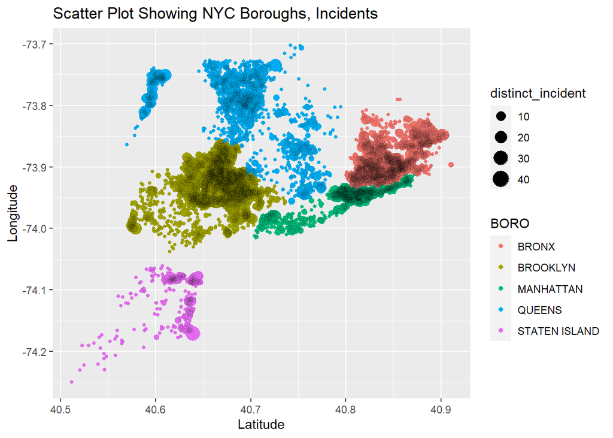

```r
ggplot(distinct_lat_long, aes(x=Latitude, y=Longitude, color=BORO)) +
        geom_point(aes(size=distinct_incident)) +
        geom_point(shape = 1, aes(size=distinct_incident), alpha = 0.1, colour = "black") +
                    labs(x = "Latitude", y = "Longitude", title='Scatter Plot Showing NYC Boroughs, Incidents')
```

We can visualize the approximate location of boroughs and the size of incidents for various locations

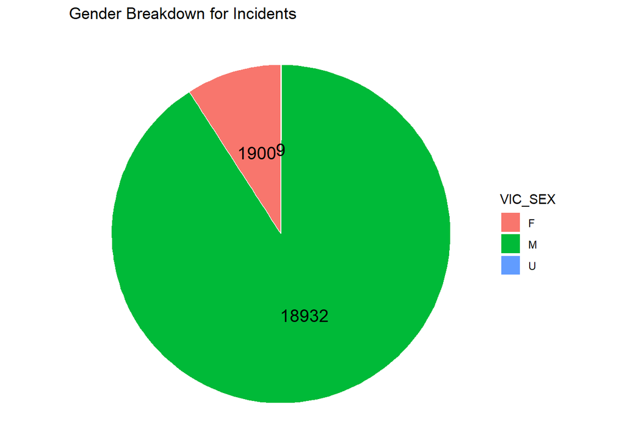

```r
distinct_gender <- police_shootings %>% group_by(VIC_SEX) %>%
                    summarize(distinct_incident = n_distinct(INCIDENT_KEY))
ggplot(distinct_gender, aes(x="", y=distinct_incident, fill=VIC_SEX, label = distinct_incident)) +
                geom_bar(stat="identity", width=1, color="white") +
                          coord_polar("y", start=0) + theme_void() +
                geom_text(aes(label = distinct_incident), position = position_stack(vjust = 0.5), size=5) +
                    labs(title='Gender Breakdown for Incidents')
```

## Add a linear model to see if number of shootings have been increasing

```r
linear_incidents = lm(distinct_incident~YEAR_MONTH, data=distinct_year_month)
```

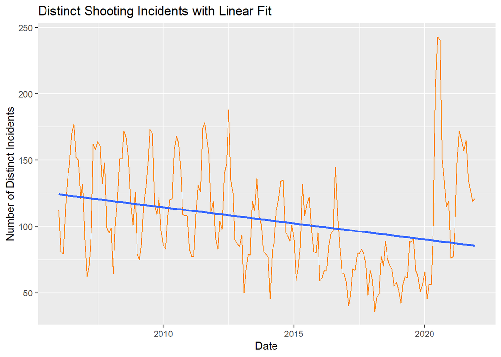

```r
ggplot(distinct_year_month, aes(x=YEAR_MONTH,
                                y=distinct_incident, group = 1)) +
                                geom_line(color = "darkorange1") +
                                geom_smooth(method='lm', se = FALSE) +
                    labs(x = "Date", y = "Number of Distinct Incidents", title='Distinct Shooting Incidents with Linear Fit')
```

The linear model suggests the number of shooting has decreased

```r
summary(linear_incidents)
```

```
##
## Call:
## lm(formula = distinct_incident ~ YEAR_MONTH, data = distinct_year_month)
##
## Residuals:
##     Min      1Q  Median      3Q     Max
## -59.511 -28.362  -6.566  27.068 154.043
##
## Coefficients:
##               Estimate Std. Error t value Pr(>|t|)
## (Intercept) 211.448032  26.170392   8.080 7.36e-14 ***
## YEAR_MONTH   -0.006641   0.001621  -4.097 6.20e-05 ***
## ---
## Signif. codes:  0 '***' 0.001 '**' 0.01 '*' 0.05 '.' 0.1 ' ' 1
##
## Residual standard error: 37.9 on 190 degrees of freedom
## Multiple R-squared:  0.08116,    Adjusted R-squared:  0.07633
## F-statistic: 16.78 on 1 and 190 DF,  p-value: 6.2e-05
```

The R value suggests a poor fit, which is expected given the seasonality in the data and the outlier for the pandemic years.

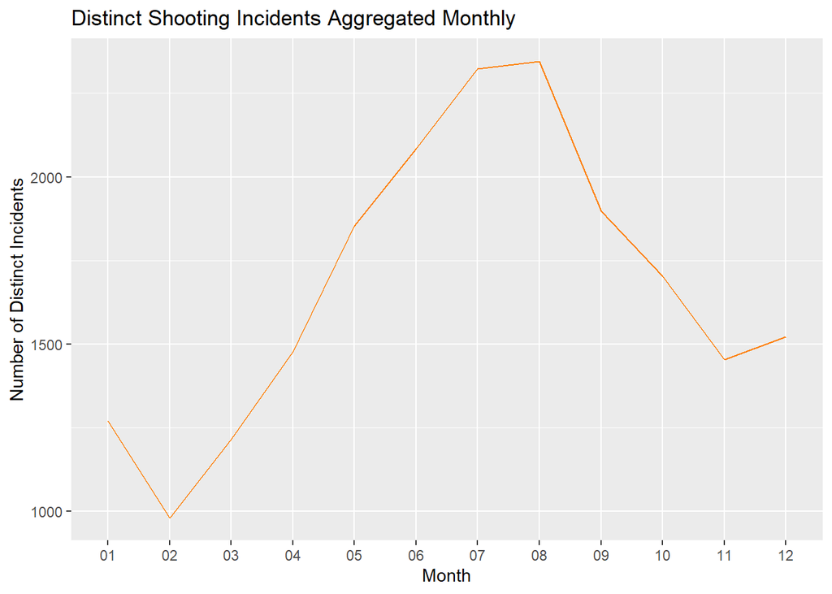

```r
distinct_monthly <- police_shootings %>% group_by(MONTH) %>%
                                summarize(distinct_incident = n_distinct(INCIDENT_KEY))
ggplot(distinct_monthly, aes(x=MONTH,
                                y=distinct_incident, group = 1)) +
                                geom_line(color = "darkorange1") +
                    labs(x = "Month", y = "Number of Distinct Incidents", title='Distinct Shooting Incidents Aggregated Monthly')
```

Summer months have the highest number of shootings.

## Possible Bias

The collected data itself can be biased due to higher police presence and incidents in communities that have predominantly minority population, further exploration of the PERP_RACE fields and understanding of New York City’s racial distribution areas can help shed more light into it.